# R Notebook for AER examples

## Introduction

This example shows how you can combine R with HTML (or other outputs, such as Word). This is done by embedding R code into a special document known as [R Markdown](http://rmarkdown.rstudio.com) Notebook. This formats text in a simple way, and runs code, presenting the output. The code can be shown, or hidden

This RMarkdown Notebook is being used with AER package of Applied Econometrics, which contains a large number of (old) datasets as well as the functions to perform econometric analysis.

The aim is to kill 2 birds with one stone - hopefully it is not too much to take in.

Try executing chunks by clicking the *Run* button within the chunk or by placing your cursor inside it and pressing *Cmd+Shift+Enter*.

## Using AER package as an example.

“Applied Econometrics with R” (Kleiber and Zeileis 2008, Springer-Verlag, ISBN 978- 0-387-77316-2, pp. vii+222) is the first book on applied econometrics using the R system for statistical computing and graphics (R Core Team 2019). It presents hands-on exam- ples for a wide range of econometric models, from classical linear regression models for cross-section, time series or panel data and the common non-linear models of microecono- metrics, such as logit, probit, tobit models as well as regression models for count data, to recent semiparametric extensions. In addition, it provides a chapter on programming, including simulations, optimization and an introduction to R tools enabling reproducible econometric research. The methods are presented by illustrating, among other things, the fitting of wage equations, growth regressions, dynamic regressions and time series models as well as various models of microeconometrics.

### A panel study on income dynamics 1982

```r
#########################################
## Panel study on income dynamics 1982 ##
#########################################
## data
data("PSID1982", package = "AER")
## Table 4.1
earn_lm <- lm(log(wage) ~ . + I(experience^2), data = PSID1982)
summary(earn_lm)
```

```
##
## Call:
## lm(formula = log(wage) ~ . + I(experience^2), data = PSID1982)
##
## Residuals:
##     Min      1Q  Median      3Q     Max
## -1.0271 -0.2292  0.0155  0.2231  1.1314
##
## Coefficients:
##                   Estimate Std. Error t value Pr(>|t|)
## (Intercept)      5.5900930  0.1901125  29.404  < 2e-16 ***
## experience       0.0293801  0.0065241   4.503 8.09e-06 ***
## weeks            0.0034128  0.0026776   1.275 0.202973
## occupationblue  -0.1615216  0.0369073  -4.376 1.43e-05 ***
## industryyes      0.0846626  0.0291637   2.903 0.003836 **
## southyes        -0.0587635  0.0309069  -1.901 0.057755 .
## smsayes          0.1661912  0.0295510   5.624 2.90e-08 ***
## marriedyes       0.0952370  0.0489277   1.946 0.052077 .
## genderfemale    -0.3245574  0.0607294  -5.344 1.30e-07 ***
## unionyes         0.1062775  0.0316755   3.355 0.000845 ***
## education        0.0571935  0.0065910   8.678  < 2e-16 ***
## ethnicityafam   -0.1904220  0.0544118  -3.500 0.000502 ***
## I(experience^2) -0.0004860  0.0001268  -3.833 0.000141 ***
## ---
## Signif. codes:  0 '***' 0.001 '**' 0.01 '*' 0.05 '.' 0.1 ' ' 1
##
## Residual standard error: 0.3256 on 582 degrees of freedom
## Multiple R-squared:  0.4597, Adjusted R-squared:  0.4485
## F-statistic: 41.26 on 12 and 582 DF,  p-value: < 2.2e-16
```

```r
## Table 13.1
union_lpm <- lm(I(as.numeric(union) - 1) ~ . - wage, data = PSID1982)
union_probit <- glm(union ~ . - wage, data = PSID1982, family = binomial(link = "probit"))
union_logit <- glm(union ~ . - wage, data = PSID1982, family = binomial)
```

### Further examples, US consumption data (1950-1993) using personal income and expenditure data

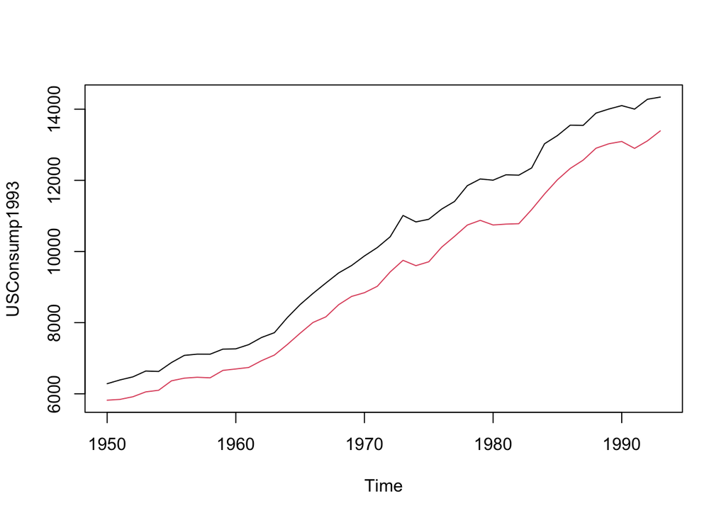

```r
#####################################
## US consumption data (1950-1993) ##
#####################################
## data
data("USConsump1993", package = "AER")
plot(USConsump1993, plot.type = "single", col = 1:2)
```

```r
## Chapter 5 (p. 122-125)
```

### Perform the Durbin Watson test for auto-correlation

In a regression model’s output. The DW statistic ranges from zero to four, with a value of 2.0 indicating zero autocorrelation. Values below 2.0 mean there is positive autocorrelation and above 2.0 indicates negative autocorrelation. The test reports DW measure of 0.46, suggesting the results are auto-correlated.

[output not shown]

[output not shown]

### A Newey–West

A Newey–West estimator is used in statistics and econometrics to provide an estimate of the covariance matrix of the parameters of a regression-type model where the standard assumptions of regression analysis do not apply.

```r
## Newey-West standard errors (Table 5.5, p. 125)
coeftest(fm, vcov = NeweyWest(fm, lag = 3, prewhite = FALSE, adjust = TRUE))
```

```
##
## t test of coefficients:
##
##               Estimate Std. Error t value Pr(>|t|)
## (Intercept) -65.795821 133.345400 -0.4934   0.6243
## income        0.915623   0.015458 59.2319   <2e-16 ***
## ---
## Signif. codes:  0 '***' 0.001 '**' 0.01 '*' 0.05 '.' 0.1 ' ' 1
```

### Compute the recursive residuals

A structural change in mid-1980s

```r
library("strucchange")
## Recursive residuals
rr <- recresid(fm)
rr
```

```
##  [1]   24.900681   30.354827   50.893291   63.260389  -49.805907  -28.404311
##  [7]  -31.520559   53.194256   67.696114   -2.646556    9.679147   39.658827
## [13]  -40.126557  -30.260756    2.605633  -78.941467   27.185066   64.363195
## [19]  -64.906717  -71.641013   70.095867 -113.475323  -85.633171  -29.427630
## [25]  128.328459  220.693133  126.591749   78.394247  -25.955574 -124.178686
## [31]  -90.845193  127.830581  -30.794629  159.780872  201.707127  405.310561
## [37]  390.953841  373.370919  316.431235  188.109683  134.461285  339.300414
```

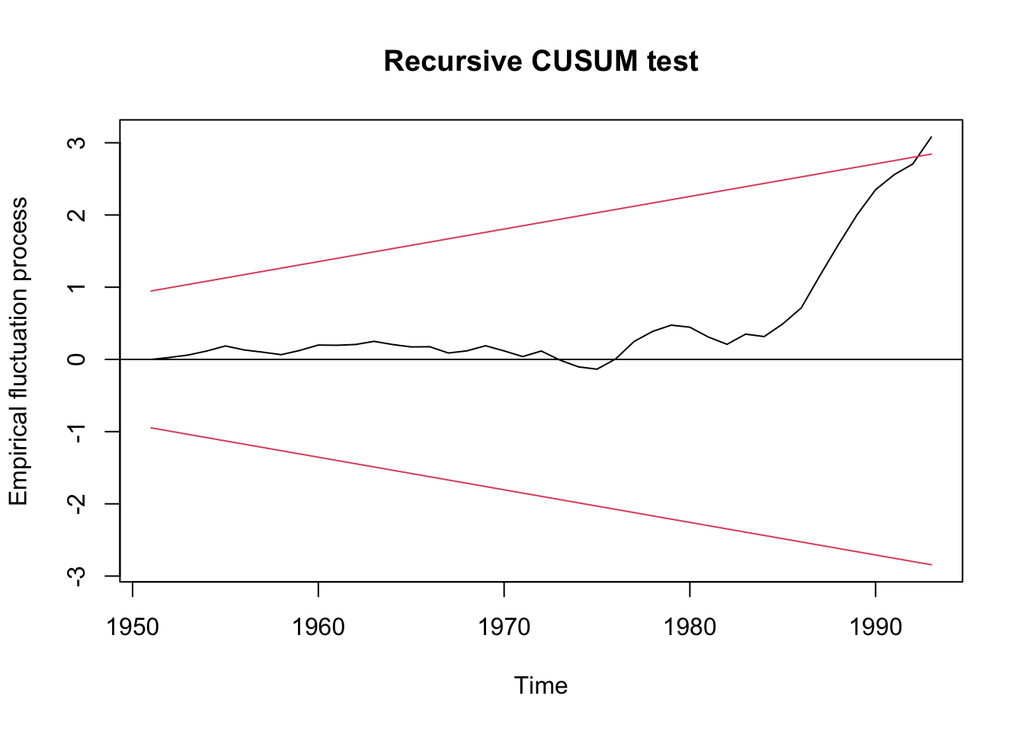

```r
## Recursive CUSUM test
rcus <- efp(expenditure ~ income, data = USConsump1993)
plot(rcus)
```